589

Effect of Probiotics on Central Nervous System

Functions in Animals and Humans: A Systematic

Review

**Huiying Wang,**

**1,2,3** **In-Seon Lee,**

**1,2,3** **Christoph Braun,**

**2,4** **and Paul Enck**

**1***

1Department of Psychosomatic Medicine and Psychotherapy, University of Tübingen, Germany;

2MEG Center, University Hospital Tübingen,

Germany;

3Graduate Training Center of Neuroscience, IMPRS for Cognitive and Systems Neuroscience, Tübingen, Germany; and

4CIMeC, Center

for Mind/Brain Sciences, University of Trento, Italy

To systematically review the effects of probiotics on central nervous system function in animals and humans, to summarize effective

interventions (species of probiotic, dose, duration), and to analyze the possibility of translating preclinical studies. Literature searches

were conducted in Pubmed, Medline, Embase, and the Cochrane Library. Only randomized controlled trials were included. In total, 38

studies were included: 25 in animals and 15 in humans (2 studies were conducted in both). Most studies used Bifidobacterium (eg,

B. longum, B. breve, and B. infantis) and Lactobacillus (eg, L. helveticus, and L. rhamnosus), with doses between 10

9 and 10

10 colony-

forming units for 2 weeks in animals and 4 weeks in humans. These probiotics showed efficacy in improving psychiatric disorder-

related behaviors including anxiety, depression, autism spectrum disorder (ASD), obsessive-compulsive disorder, and memory abilities,

including spatial and non-spatial memory. Because many of the basic science studies showed some efficacy of probiotics on central

nervous system function, this background may guide and promote further preclinical and clinical studies. Translating animal studies

to human studies has obvious limitations but also suggests possibilities. Here, we provide several suggestions for the translation of

animal studies. More experimental designs with both behavioral and neuroimaging measures in healthy volunteers and patients are

needed in the future.

**(J Neurogastroenterol Motil 2016;22:589-605)**

**Key Words**

Animals; Anxiety; Depression; Humans; Probiotics

Received: January 27, 2016 Revised: April 25, 2016 Accepted: May 18, 2016

This is an Open Access article distributed under the terms of the Creative Commons Attribution Non-Commercial License (http://creativecommons.

org/licenses/by-nc/4.0) which permits unrestricted non-commercial use, distribution, and reproduction in any medium, provided the original work

is properly cited.

*Correspondence: Paul Enck, PhD

Department of Psychosomatic Medicine and Psychotherapy, University Hospital Tübingen, Osianderstr. 5, 72076 Tübingen,

Germany

Tel: +49-7071-2989118, Fax: +49-7071-294382, E-mail: paul.enck@uni-tuebingen.de

JNM

J Neurogastroenterol Motil, Vol. 22 No. 4 October, 2016

pISSN: 2093-0879 eISSN: 2093-0887

http://dx.doi.org/10.5056/jnm16018

Review

Journal of Neurogastroenterology and Motility

ⓒ 2016 The Korean Society of Neurogastroenterology and Motility

J Neurogastroenterol Motil, Vol. 22 No. 4 October, 2016

www.jnmjournal.org

**Introduction**

The microbiota, the ecological community of commensal, sym-

biotic, and pathogenic microorganisms literally sharing our body

space, includes more than 10 times the number of host cells to hu-

man cells.

1 The majority of the microbiome lives in the gastrointes-

tinal (GI) tract and is composed of 10 100 trillion microorganisms,

containing 100 times as many genes as our genome.

2 Symbiosis of

the gut microbiota (GM) can maintain a normal physiology in the

host, while dysbiosis of the GM can shift the balance and may in-

duce diseases.

Recent studies have found a role for the GM in the gut-brain

axis, which can alter minds and behaviors through the central ner-

590

Huiying Wang, et al

Journal of Neurogastroenterology and Motility

vous system (CNS).

3-8 Maintaining GM symbiosis is important for

retaining healthy CNS functions. Sudo’s study was the first linking

the GM and CNS, showing an increased hypothalamic-pituitary-

adrenal (HPA) stress response and decreased brain-derived

neurotrophic factor (BDNF) levels in the hippocampus of germ-

free (GF) mice.

9 Recently, researchers have found a relationship

between the GM and CNS-related disorders in humans, such as

Parkinson’s disease and autism: overall diversity and individual ge-

nus abundances were associated with their symptoms.

10-12

Probiotics are defined as “live micro-organisms which, when

administered in adequate amounts, confer a health benefit on the

host”.

13,14 Some types of probiotics have been used to treat gastro-

intestinal disorders, such as irritable bowel syndrome (IBS).

15-18

Also, probiotics have been studied in relation to altering visceral

pain responses.

19 Recently they have been reported to have an in-

fluence in the CNS by altering the GM composition.

3,8 Studies

using probiotics to change CNS functions have increased over the

last 10 years. The CNS functions mostly reported being altered by

probiotics are psychiatric disorders and memory abilities. Studies

in animals and humans have found, and reviews have summarized,

potential mechanisms underlining these probiotic effects (Fig. 1).

First, probiotics may directly alter CNS biochemistry, such as by

affecting levels of BDNF, g-aminobutyric acid (GABA), serotonin

(5 hydroxytryptamine; 5 HT), and dopamine (DA), thus influenc-

ing mind and behavior.

20-24 Both the vagus and the enteric nerves

are involved in this gut-brain interaction and can be affected by

certain probiotics.

22,23 The HPA stress response, which regulates

mood and emotion, has frequently been shown to be attenuated by

probiotics, decreasing corticosteroid (CORT) levels.

25 The immune

system can be influenced by probiotics, limiting pro-inflammatory

cytokine production and inflammation, which, in turn, can affect

the endocrine and nervous systems.

26,27 Probiotics manipulate GM

by increasing microbiota diversity and beneficial bacteria composi-

tions.

28-30 Improved GM changes metabolites, such as short-chain

fatty acids and tryptophan, which can indirectly improve CNS

function.

26,31

While there are reviews describing effects of probiotics on CNS

function, there has been no previous systematic review that analyzes

all the current animal and human studies in the field and describes

the most effective probiotic interventions. Furthermore, animal

studies in this area outnumber human studies, because behavioral

experiments in animals are better established and standardized,

while clinical studies in humans on this topic started to increase a

few years ago and need translation from preclinical studies. How-

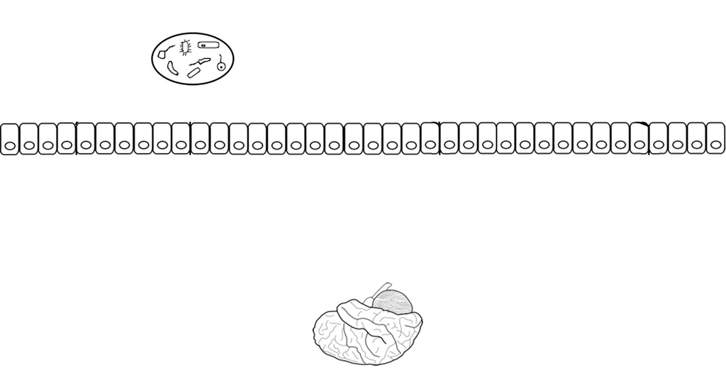

Endocrine system:

CORT, ACTH

Immune system:

cytokines

Neurochemical: 5-HT, DA,

GABA, BDNF. c-Fos

Neural system:

vagus nerve

GM

Probiotics

Metabolic: SCFA,

tryptophan

Figure 1. Mechanisms of probiotic effects on the central nervous system. Probiotics influence central nervous system (CNS) function through

direct and indirect mechanisms. Probiotics affect the hypothalamic-pituitary-adrenal (HPA) axis, by altering corticosteroid (CORT) and/or adre-

nocorticotropic hormone (ACTH) levels. The immune system is influenced by limited pro-inflammatory cytokine production and inflammation,

and this, in turn, has effects on the CNS. Probiotics can also directly alter CNS biochemistry, such as by affecting brain-derived neurotrophic fac-

tor (BDNF), c-Fos, g-aminobutyric acid (GABA), 5 hydroxytryptamine (5-HT), and dopamine (DA) levels, thus influencing mind and behavior.

The vagus and enteric nerves are also involved in this gut-brain interaction and are affected by certain probiotics. Probiotics manipulate the gut

microbiota (GM) by increasing microbiota diversity and beneficial bacteria composition. An “improved” GM changes metabolites, such as short-

chain fatty acids (SCFAs) and tryptophan, and so improves CNS function indirectly. The GM also interacts with the endocrine, immune, and neu-

ral systems.

591

Probiotics and CNS

Vol. 22, No. 4 October, 2016 (589-605)

ever, from preclinical animal models to clinical trials in humans,

there is no direct translation. To bridge the gap between preclinical

and clinical studies, a systematic review is needed to summarize ef-

fective probiotic interventions on CNS function. We first sought to

describe CNS functions that can be influenced by probiotics. Sec-

ond we provide information about probiotic interventions including

strain, dosage, and duration. Furthermore, we analyze and discuss

the potential translation of animal models to human studies.

**Methods**

Search Strategy

This systematic review was conducted according to guidelines

of the “Cochrane Handbook for Systematic Reviews of Interven-

tions”, following the Preferred Items for Systematic Reviews and

Meta-analysis guidelines.

32,33 Relevant studies were found by

searches in the Pubmed, Medline, Embase, and Cochrane Library

databases. Articles from 1950 to April 2016 were initially searched

using the search terms “(probiotic OR gut microbiota) AND

(behavior OR central nervous system)”. Additional citations were

sought using references in articles retrieved from searches. We only

included articles written in English. The first search was under-

taken by analyzing text words contained in the title and abstract,

and of the key words describing the articles. The second search was

conducted according to the citations from all identified reports and

relevant review articles.

Study Selection

We included all animal and human studies using different

strains of probiotics. In human studies reports of both healthy vol-

unteers and patients were considered.

The abstracts of the retrieved papers were screened for match-

ing the following criteria: (1) the study included a probiotic inter-

vention and (2) the study tested CNS function. After exclusion of

non-relevant studies, the remaining articles were screened for the

following criteria: (1) the study was described as a randomized con-

trolled study (RCT), (2) the study was described as double-blind

if studied in human participants, (3) the study involved use of pro-

biotics in single- and/or multi-strains and those that only used pre-

biotics or antibiotics were not included, and (4) the study included

measures of behavioral experiments, neuropsychological measures

(eg, electroencephalography, magnetoencephalography, and func-

tional magnetic resonance imaging). Those that only involved neu-

rophysiological measures were not included in the qualitative analy-

sis but only in the Discussion (eg, measuring neurochemical level,

HPA axis activity) because different studies tested quite divergent

aspects of lower-level CNS activity.

Data Collection and Analysis

A data extraction and assessment form from the Cochrane Col-

laboration was used to further exclude inappropriate studies and to

extract data we needed to analyze.

33 Double extraction of data was

conducted: important data included the source of participants (ani-

mal species/strains, patient types), intervention groups (probiotic,

placebo, or any other intervention), sample size, duration of inter-

ventions, and outcomes (behavioral changes as the primary outcome

and lower-level changes [eg, biochemical changes] as secondary

outcomes).

We assessed the quality of each study included using the Qual-

ity Assessment Tool for Quantitative Studies and the Quality As-

sessment Tool for Quantitative Studies Dictionary developed by

The Effective Public Health Practice Project (EPHPP) (National

Collaborating Centre for Methods and Tools [2008]).

34

The inclusion of both animals and human studies resulted in

great heterogeneity of participants, interventions, and CNS func-

tions measured. The outcomes of each study were described. A

qualitative synthesis of selected studies was made with the aim

of coming to conclusions about which probiotic interventions, at

which dose, and for how long, were more/most effective with regard

to certain CNS functions. Because of the heterogeneity of designs a

meta-analysis was deemed to be inappropriate.

**Results**

In total, 46 potentially relevant citations were obtained through

the primary search strategy, which included animal and human

studies, after excluding reviews (n = 98) (systematic reviews,

narrative reviews, respective reviews, and systematic reviews and

meta-analyses), other articles including comments, hypotheses,

viewpoints, opinions, and editorials (n = 13), studies without the

use of a probiotic (n = 33), and studies not focusing on CNS func-

tion (n = 16) (Fig. 2). Many articles concerned the potential, and

demonstrated mechanisms of the effects, of GM and/or probiotics

on CNS function. However, we only included studies that clearly

described probiotics as interventions, and excluded studies only

measuring GM composition when investigating CNS function. Af-

ter the full screen, 8 more studies were excluded: four studies lacked

a control arm or blinding, and 4 studies did not measure CNS

functions at the behavioral level. In total, 38 studies remained for

592

Huiying Wang, et al

Journal of Neurogastroenterology and Motility

the qualitative analysis. Of them, 15 were in humans and 25 were in

animals (2 studies were conducted in humans and animals).

Animal Studies

Of the 25 studies, 19 provided explicit information in the Ma-

terials and Methods section on the numbers of animals allocated

to each treatment group, and they accounted for all the animals in

their results, while 6 studies provided specifics regarding treated

animals only in the pertinent areas of the Results section. Results

from the quality assessment tool for quantitative studies showed all

studies were strong in global ratings for selection bias, study design,

confounders, blinding, data collection method, and withdrawals and

dropouts (no weak rating): 15 studies described assigning animals

randomly to treatment groups or control, although these animal

studies were supposed to be RCTs. Only four studies might have

confounders because they used both male and female animals while

the other studies only used single gender animals, excluding the

effect of gender on the results. Only 13 studies reported that experi-

menters were blinded toward the interventions or exposure status

of the participants (we included the other 12 studies that did not

describe blinding, because animals were not aware of the research

question or intervention, and we ignored potential effects of the ex-

perimenter). Data collection tools shown in all studies were consid-

ered valid and reliable; no study reported withdrawals or drop outs.

Although all of studies examined were on rodents (mice or rats),

the selection of animals was heterogeneous in some respects: strains

of animals and health conditions of the animals. Studies were also

heterogeneous in the CNS functions they were looking at, the ex-

perimental models they used, the probiotics they used, and the dose

and duration of the probiotic interventions. Due to the heterogeneity

of the included studies, we only described the results based on the

interventions and measurements of the CNS functions (Table 1).

Most of the studies (18/25) investigated the effects of a single

strain of probiotics. In 18 studies using single-strain probiotics,

seven used Bifidobacterium, eleven used Lactobacillus, and one

used Clostridium (one used both Bifidobacterium and Lactobacil-

lus). Almost all the studies found significant effects on measured

CNS functions, except for one testing effect of Bifidobacterium

infantis on depression-like behavior. The concentration of the effec-

tive probiotic interventions ranged from 10

7 to 10

units (CFU), with the most using 10

9 (14/25) or 10

10 (6/25) CFU

per animal per day. The duration of the probiotic treatments ranged

245 of records identified

through database searching

9 of additional records

identified through other sources

160 of records excluded:

98 reviews

13 other (comment,

hypothesis, viewpoint,

opinion, editorial)

16 not CNS functions

33 not probiotic

46 of full-text articles

assessed for eligibility

38 of studies included in

qualitative synthesis

8 of full-text articles

excluded:

2 no placebo control

2 no blinding

4 no behavioural measure

Figure 2. Preferred reporting items for

systematic reviews and meta-analyses

(PRISMA) scheme of retrieved litera-

ture. CNS, central nervous system.

593

Probiotics and CNS

Vol. 22, No. 4 October, 2016 (589-605)

Table 1. Studies of Effects of Probiotics on Central Nervous System Functions in Animals

Study

Animal

CNS function

Probiotic

(species, dosage

[CFU/day], duration)

Outcome

(behavioral level)

Secondary outcome

Liu et al,

20

2016

ELS mice

Naïve mice

Locomotor activity

(open-field test)

Anxiety (open-field test,

elevated plus maze)

Depression (sucrose-

preference test,

forced-swimming test)

L. plantarum PS128

10

9

28 days

Locomotor activity ↑

Anxiety (only in naïve

mice) ↓

Depression (only in ELS

mice) ↓

Corticosteroids (CORT) ↓

Cytokine: inflammatory cytokine

TNF-a, IL-6 ↓, anti-inflammatory

cytokine IL-10 ↑

Brain monoamines and metabo-

lites: 5-HT ↑, 5-HIAA ↓, DA ↑,

DOPAC ↓, HVA ↓

Liu et al,<sup>21</sup>

2016

GF mice

Locomotor activity

(open-field test)

Anxiety (elevated-plus

maze)

Depression

(forced-swimming test)

L. plantarum PS128

10

9

16 days

Locomotor activity ↑

Anxiety ↓

Depression (-)

CORT: NA

Brain monoamines and

metabolites: DA ↑, HVA ↑, 5-HT ↑

and 5-HIAA ↑

Liang et al,

38

2015

SPF CRS rats

Stress (chronic-restraint

stress)

Depression (sucrose-

preference test)

Anxiety (elevated-plus

maze, open-field test)

Non-spatial memory

(object-recognition test,

object-placement test)

L. helveticus NS8

10

9

Initial 21 days

Anxiety ↓

Depression ↓

Non-spatial memory ↑

CORT and ACTH ↓

Cytokines: IL-10 ↑

Brain monoamines: 5-HT ↑ and

NE ↑

BDNF expression ↑

Wang et al,<sup>30</sup>

2015

Ampicillin-treated

rats

Anxiety (elevate-plus

maze)

Spatial memory

(Morris water maze)

L. fermentum N93

10

9

Initial 30 days

Anxiety ↓

Spatial memory ↑

CORT and ACTH ↓

Brain monoamines: MR ↑,

NMDA ↑, GR: NA

Brain BDNF: NA

Colon inflammation:

myeloperoxidase activity ↓

Fecal microbiota: Bacteroides ↑,

C. coccoides ↓, Firmicutes ↓,

Lactobacillus ↑

Smith et al,

29

2014

RagI

-/- mice

Stress response

(water-avoidance stress)

Anxiety (light/dark

box test)

Non-spatial memory

(novel- object test)

L. rhamnosus R0011 +

L. helveticus R0052

6 × 10

9

28 days

Anxiety ↓

Non-spatial memory ↑

CORT: NA

Brain c-Fos expression ↑

Intestinal permeability ↓

Fecal microbiota: Bacteroides ↑,

Enterobacteriaceae ↑, Firmicutes ↑

Luo et al,

42

2014

Hyperammone-

mia rats

Anxiety (elevate-plus

maze)

Spatial memory

(Morris water maze)

L. helveticus NS8

10

9

14 days

Anxiety ↓

Spatial memory ↑

Neuroinflammation: PGE2 ↓,

IL-1β ↓

Brain monoamines: 5-HT ↓

Plasma kynurenine pathway:

KYN/TRP ↑, KA/KYN ↓

Savignac et

al,<sup>36</sup> 2014

Mice

Anxiety (defensive marble

burying, elevated-plus

maze, open field)

depression (tail-suspen-

sion test, forced-swim

test)

B. longum 1714/

10<sup>B. breve 1205</sup>

9

Initial 21 days

B. longum:

Anxiety ↓

Depression ↓

B. breve:

Anxiety ↓

CORT: NA

Ohland et

al,

37 2013

Il-10 deficient

mice

Anxiety (elevated

Barnes Maze)

Spatial memory

(elevated Barnes maze)

L. helveticus R0052

10

9

21 days

Anxiety ↓

Spatial memory ↑

Colon inflammation ↓

Cytokines: NA

CORT ↓

SCFA metabolites: NA

594

Huiying Wang, et al

Journal of Neurogastroenterology and Motility

Table 1. Continued

Study

Animal

CNS function

Probiotic

(species, dosage

[CFU/day], duration)

Outcome

(behavioral level)

Secondary outcome

Messaoudi

et al,

39 2011

Rats

Anxiety (conditioned

defensive burying)

B. longum R0175 +

10<sup>L. helveticus R0052</sup>

9

14 days

Anxiety ↓

NA

Bravo et al,

23

2011

Mice

Anxiety (open arms,

elevated-plus maze,

fear conditioning)

Depression

(forced-swim test)

L. rhamnosus JB-1

10

9

28 days

Anxiety ↓

Depression ↓

CORT ↓

GABA receptor expression influence

depending on brain areas

Probiotic effect via vagus nerve

Bercik et

al,<sup>22</sup> 2011

Chronic colitis

mice

Anxiety (step-down test)

B. longum NCC3001

10

10

14 days

Anxiety ↓

Colon inflammation: NA

Brain BDNF expression: NA

Enteric neurons excitability ↓

Probiotic effect via vagus nerve

Bercik et

al,<sup>35</sup> 2010

T-muris infected

mice

Anxiety (light/dark

behavior, step-down test)

B. longum NCC3001 /

10<sup>L. rhamnosus</sup><sup>NCC4007</sup>

10

10 days

Anxiety ↓ (B. longum only)

Colon inflammation ↓

Plasma cytokines: NA

BDNF expression ↑

(only by B. longum)

Tryptophan and kynurenine: NA

No effect of vagotomy

Singh et al,

40

2012

Rats

CFS and depression

induced by forced-swim

test (immobility period,

post-swim fatigue time)

L. acidophilus as LAB

10<sup>or LAB FB</sup>

7

7 days

Depression ↓ (larger effect

of LAB FB than LAB);

Brain oxido-nitrosative stress

biomarker ↓

Cytokines: TNF-a ↓

Arseneautl-

Bread et

al,<sup>41</sup> 2012

MI rats

Post-MI depression

(forced-swim test);

social behavior

(social interaction test);

emotional memory

(passive avoidance

step-down test)

B. longum R0175 +

10<sup>L. helveticus R0052</sup>

9

14 days

Depression ↓

Social interaction ↑

Non-spatial memory ↑

Cytokines: pro-inflammatory

cytokine IL-1β ↓

Intestinal barrier permeability ↓

Desbonnet

et al,<sup>27</sup> 2010

MS rats

Depression

(forced-swim test)

B. infantis 35624

10

10

Initial 40 days

Depression ↓

CORT: NA

Cytokines: IL-10 ↓

Tryptophan: NA

Brain monoamines (-)

Noradrenaline ↑

Desbonnet

et al,

26 2008

Rats

Depression

(forced-swim test)

B. infantis 35624

10

10

14 days

No behavioral change

Cytokines: pro-inflammatory cytokines

IL-6, IFN-g ↓; anti-inflammatory

cytokines IL-10 ↓

Tryptophan ↑

Brain monoamines and metabolites –

5-HIAA ↓, DOPAC ↓

Neuroendocrine: NA, CORT: NA ,

AVP: NA , CRF: NA

Liu etal,

44

2015

VaD (vascular

dementia) mice

Locomotor activity

(open-field test)

Spatial memory

(Morris water maze)

C. butyricum

WZMC1016

(CGMCC 9831)

10<sup>6</sup>/10

7/10

8

42 days

Locomotor activity ↑

Spatial memory ↑

Morphological change of

hippocampus ↓

BDNF expression ↑

Butyrate in feces and brain ↑

Fecal bacteria diversity ↑

Jeong et al,

47

2015

Aged rats

Spatial memory (Y-maze,

Morris water maze)

L. plantarum KY1032 +

10<sup>L. curvatus HY7601</sup>

10

48 days

Spatial memory ↑

Cytokines: pro-inflammatory

cytokines NF-κB, ↓

BDNF ↑

Lipidemia ↓

595

Probiotics and CNS

Vol. 22, No. 4 October, 2016 (589-605)

Table 1. Continued

Study

Animal

CNS function

Probiotic

(species, dosage

[CFU/day], duration)

Outcome

(behavioral level)

Secondary outcome

Savignac et

al,

43 2015

Mice

Non-spatial memory

(object recognition,

fear conditioning)

Spatial memory

(Barnes Maze)

B. longum 1714/

10<sup>B. breve 1205</sup>

9

initial 21 days

B. longum:

Non-spatial memory ↑

Spatial memory ↑

B. breve:

Non-spatial memory ↑

Visceral sensitivity -colon distension:

NA

CORT: NA

Gareau et

al,

45 2011

C. rodentium

infected mice

Memory dysfunction

induced by water

avoidance (novel-object

test, T-maze);

L. rhamnosus R0011 +

L. helveticus R0052

6 × 10

9

17 days

Non-spatial memory ↑

CORT ↓

Colon epithelial cell hyperplasia ↓

Cytokine: pro-inflammatory

cytokines IFN g ↓

Brain BDNF and c-Fos expression ↑

Microbiota: Firmicutes ↓,

Enterobacteriaceae ↓, Eubacteria

rectale ↓, Lactobacillus ↑

Davari et

al,

46 2013

Diabetic rats

Spatial memory

(Morris water maze)

L. acidophilus 4356 +

B. lactis 10140 +

L. fermentum

ATCC9338

2 × 10

10

56 days

Spatial memory ↑

Hippocampal long-term potentiation ↑

Serum glucose ↓ and insulin ↑

Oxidative stress biomarkers: SOD ↑,

8-OHdG ↓

Hsiao et

al,<sup>31</sup> 2013

MIA mice

Autism spectrum disorder:

Anxiety (open field,

marble burying);

Sensory gating

(prepulse inhibition);

Communicative behavior

(ultrasonic vocalizations);

Social interaction

(3-chamber social test)

B. fragilis NCTC9343

10

10

6 days

Anxiety ↓

Sensory gating ↑

Communicative behavior ↑

Social interaction (-)

Intestinal permeability ↓

Tryptophan metabolites:

indolepyruvate ↓

Microbiota: Lachnospiraceae ↓,

Bacteroidales ↓

Kantak et

al,<sup>48</sup> 2014

Male mice

obsessive-compulsive-dis-

order-like behavior (open

field, marble burying,

ultrasonic vocalizations,

intermale aggression)

L. rhamnosus GG

10<sup>(ATCC 53103)</sup>

9

14, 28 days

Locomotor behavior ↓

Marble burying ↓

Ultrasonic vocalizations (-)

Intermale aggression (-)

NA

D’Mello et

al,

49 2015

Male mice

Inflammation associated

sickness behavior

(social exploratory)

VSL#3

1.7 × 10<sup>9</sup>

10 days

Social exploratory behavior

in bile duct ligation treated

mice ↑

Intestinal permeability: NA

Cytokine: pro-inflammatory cytokine

TNF-a ↓

Monocyte infiltration ↓

Microglial activation ↓

Fecal Microbiota (-)

Takada et

al,<sup>50</sup> 2016

Male rats

Stress response to water

avoidance stress

L. casei Shirota YIT 9029

3 × 10

9

14 days

NA

CORT ↓

c-Fos expression in the paraventricular

nucleus ↓

Gastric vagal afferent activity ↑

Neuronal excitability of NTS ↑

ELS, early life stress; CORT, corticosterone; 5-HT, 5-hydroxytryptamine; 5-HIAA, 5-Hydroxyindoleacetic acid; DA, dopamine; DOPAC, 3,4-dihydroxyphen-

ylacetic acid; HVA, homovanillic acid; GF, germ free; NA, not applicable; SPF, specific pathogen free; CRS, chronic restraint stress; ACTH, adrenocorticotropic

hormone; NE, norepinephrine; BDNF, brain-derived neurotrophic factor; MR, mineralocorticoid; NMDA, N-methyl-D-aspertate; GR, glucocorticoid; RagI-/-,

RagI knockout; PGE2, prostaglandin E2; KYN, L-kynurenine; TRP, tryptophan; KA, kynurenic acid; SCFA, short-chain fatty acid; GABA, gamma-Aminobu-

tyric acid; CFS, chronic fatigue syndrome; LAB, Lactobacillus acidophilus; FB, floating bead; MI, myocardial infarction; MS, maternal separation; AVP, arginine

vasopressin; CRF, corticotrophin-releasing factor; VaD, vascular dementia; NF-κB, nuclear factor-kappa B; SOD, superoxide dismutase; 8-OHdG, 8-hydroxy-

2’deoxyguanosine; MIA, maternal immune activation; VSL#3, a high-concentration probiotic preparation of 8 live freeze-dried bacterial (Lactobacillus casei,

Lactobacillus plantarum, Lactobacillus acidophilus, Lactobacillus bulgaricus, Bifidobacterium longum, Bifidobacterium breve, Bifidobacterium infantis, and Strep-

tococcus thermophiles); NTS, nucleus tractus solitary; B. breve, Bifidobacterium breve; B. fragilis, Bifidobacterium fragilis; B. infantis, Bifidobacterium infantis;

B. lactis, Bifidobacterium lactis; B. longum, Bifidobacterium longum; C. butyricum, Clostridium butyricum; C. coccoides, Clostridium coccoides; C. rodentium,

Citrobacter rodentium; L. acidophilus, Lactobacillus acidophilus; L. casei, Lactobacillus casei; L. curvatus, Lactobacillus curvatus; L. fermentum, Lactobacillus

fermentum; L. helveticus, Lactobacillus helveticus; L. plantarum, Lactobacillus plantarum; L. rhamnosus, Lactobacillus rhamnosus.

596

Huiying Wang, et al

Journal of Neurogastroenterology and Motility

functions in animals were analyzed and described in the following

text.

Anxiety

Twelve studies tested anxiety-like behavior in animals (mice

or rats). The anxiety-like behaviors were evaluated with the elevate

plus/Barnes maze, light/dark box, defensive burying, open field/

arms, fear conditioning, and step-down tests. Three of them used a

single strain of Bifidobacterium longum, all with positive results, ie,

the animals showed less anxious behavior.

22,35,36 Two studies using

Lactobacillus helveticus also found reduced anxiety-like behaviors

in immune-deficient mice and chronically restrained rats.

29,37,38

Two studies used Lactobacillus rhamnosus but only one showed

reduced anxiety behaviors.

23,35 Two studies using Lactobacillus

plantarum also found alleviated anxiety levels in mice after the in-

tervention.

20,21 Bifidobacterium breve and Lactobacillus fermentum

were used once each and showed anxiolytic effects.

30,36 Two studies

using multi-strain probiotic combinations of L. rhamnosus + L.

helveticus and B. longum + L. helveticus found reduced anxious

behavior.

29,39

Depression

Nine studies focused on depression and all reported positive re-

sults except one. Depression-like behaviors were measured with the

tail-suspension, forced-swim, and sucrose-preference tests. B. in-

fantis was used twice but only one study found reduced depression-

rhamnosus, and L. helveticus was also used once and all showed

antidepressant effects.

23,26,27,36,40 Two studies tested L. plantarum,

but it only had an effect in mice with the early life stress of maternal

separation.

20,21 One study used a multi-strain combination of B.

longum + L. helveticus and also showed positive effects.

41

Cognitive function

Eleven studies tested cognitive function, and all showed the

probiotics to be beneficial for memory performance. Spatial mem-

ory was tested with the Morris water maze and the Barnes maze

tests; other non-spatial memory abilities were measured with the

novel object, fear conditioning, passive avoidance step-down, and

T-maze tests.

Single strains of B. longum, B. breve, and L. helveticus were

effective on both spatial and non-spatial memories.

37,38,42,43 Single

strains of L. fermentum and Clostridium butyricum improved

spatial memory ability.

30,37,42,44 Multi-strain probiotics that were as-

sessed to be effective with regard to non-spatial memory included

combinations of L. rhamnosus + L. helveticus

29,45 and B. longum

+ L. helveticus,

41 and combinations of Lactobacillus acidophilus

+ B. lactis + L. fermentum and L. plantarum + Lactobacillus

curvatus in spatial memory.

46,47

Autism spectrum disorder and obsessive-compulsive

disorder

Autism spectrum disorder-related behaviors were tested with

the open field and marble- burying tests for anxiety, the pre-pulse

inhibition test for sensorimotor, ultrasonic vocalization for com-

municative, and the three-chamber social test for social interaction

behaviors. Bifidobacterium fragilis improved behaviors related to

the ASD in maternal immune activation mice, including anxiety-

like behavior, sensory gating and communicative behavior, but not

social interaction behavior.

31

Obsessive-compulsive disorder-related behaviors were also

measured with the open field, marble burying, pre-pulse inhibition,

ultrasonic vocalization and 3-chamber social tests. L. rhamnosus

was found to be able to decrease obsessive-compulsive disorder-like

behaviors in mice, but only locomotor ability and anxiety level. No

effect was found in communicative or social interaction behaviors.

However, a recent study investigated sickness behavior using a so-<sup>48</sup>

cial investigative behavior paradigm, and found VSL#3 improved

sickness behavior with increased social exploratory behaviors.

49

Stress response

Four studies involved stress induction to test behavioral re-

sponse to stress. Stress was induced, with water avoidance stress as

an acute stressor

29,45,50 and maternal separation as a chronic stressor.

Acute stress was used to induce anxiety, memory dysfunction and <sup>27</sup>

HPA response; chronic stress was used to induce depression.

Anxiety behavior was not successfully induced by water

avoidance stress, while memory dysfunction was induced only in

Gareau’s study.

45 A probiotic combination of L. rhamnosus + L.

helveticus prevented non-spatial memory dysfunction induced by

acute stress.

45 One study only measured plasma corticosterone levels

in response to acute stress and found a significant decrease due to

Lactobacillus casei Shirota intervention.

50 For behavioral changes

caused by chronic stress exposure, B. infantis normalized depres-

sion-like behavior induced by maternal separation.

27

597

Probiotics and CNS

Vol. 22, No. 4 October, 2016 (589-605)

Mechanisms of action

In addition to outcomes on behavioral levels, we also collected

data at the physiological level, exploring endocrine, immune, neural

chemical, and metabolic changes due to probiotics. Most of the

studies investigated serum corticosteroid levels and found they were

decreased by various probiotics: L. plantarum, L. helveticus, L.

fermentum, L rhamnosus, and L. casei Shirota.

20,23,30,37,44,45,50 Adre-

nocorticotropic hormone (ACTH) could also be decreased by L.

helveticus and L. fermentum.

30,38 Colon inflammation was alleviated

and cytokine levels were influenced: inflammatory cytokines such as

IL-6 and TNF-a were decreased and anti-inflammatory cytokines

such as IL 10 were increased.

20,30,35,37,38,40,42,45,47,49 These immune-ef-

fective probiotics were L. plantarum, L. helveticus, L. fermentum,

L. acidophilus, B. longum, and L. rhamnosus. Brain monoamines,

such as 5-HT and DA, could be increased by the probiotics L.

plantarum, L. helveticus, and B. infantis, while their metabolites

were reduced.

20,26,38 GABA receptor expression could be influenced

by L. rhamnosus, depending on the brain area.

23 Brain BDNF

and c-Fos mRNA expression increased after probiotic intervention

with L. helveticus, L. plantarum, L. rhamnosus, B. longum, and

C. butyricum, while c-Fos in the hypothalamus paraventricular

nucleus was decreased by L. casei Shirota.

35,38,44,45,47 Two studies

found effects of L. rhamnosus and B. longum that were mediated

via the vagus nerve (ie, no effect in vagotomized mice),

22,23 and one

study found L. casei Shirota to enhance gastric vagal afferent activ-

ity.

50 Enteric neuron excitability was inhibited by B. longum,

22 while

visceral sensitivity by colon distension was unaffected.

43 One study

found that a probiotic formulation of B. longum + L. helveticus re-

duced intestinal barrier permeability.

31,41 Probiotics L. helveticus, B.

infantis, and B. fragilis influenced metabolites by enhancing serum

tryptophan levels and inhibiting its metabolites.

26,31,42 Several studies

conducted microbiota analyses on the fecal samples and found fe-

cal microbiota were altered by probiotics: for example, Bacteroides

and Lactobacillus were increased and Firmicutes decreased by L.

fermentum.

29-31,44,45 More details are shown in Table 1.

Human Studies

In total, 15 human studies were included. All of the selected

studies had strong ratings in the quality assessment tool for quanti-

tative studies, although one of the studies did not describe the age

and gender of the participants in each group.

51 Among the 15 stud-

ies, 8 used a single-strain probiotic (L. casei, L. casei subsp. rham-

nosus, L. casei Shirota, L. plantarum, and B. infantis), of which 2

used probiotic containing milk, and the other 7 studies used multi-

strain probiotics. Eight of the 15 studies found significant effects

of the probiotic interventions. Doses of the effective interventions

ranged from 10

10, and the duration of the treatments

ranged from 20 days to 8 weeks. Doses around 10

9 (5/8) and 10

(3/8) were used most often. Durations were most commonly 4 (6/15) <sup>10</sup>

and 8 (4/15) weeks. Due to the heterogeneity of the studies (eg,

probiotic interventions and measurements of CNS functions), we

only describe the results based on the different interventions (Table

2).

Psychiatric conditions

Here, we summarize the studies on depression, anxiety, and/or

mood together, because in most of the studies, questionnaires that

tested healthy participants with respect to anxiety, depression, dis-

tress levels, mood state, and behavior problems.

39,51-62 The measure-

ment tools included the General Health Questionnaire (GHQ),

the Depression Anxiety and Stress Scale (DASS), the Leiden

Index of Depression Sensitivity-Revised (LEIDS-r), the Positive

and Negative Symptom Scale (PANSS), the State-Trait Anxiety

Inventory (STAI), the Development Behavior Checklist (DBC),

the Beck Depression Inventory (BDI), the Beck Anxiety Inventory

(BAI), the Hopkins Symptom Checklist (HSCL-90), the Hospital

Anxiety and Depression Scale (HADS), the Perceived Stress Scale

(PSS), the Coping Checklist (CCL) (also used to counter the stress

of daily life), and the questionnaire-based Profile of Mood State

(POMS). Due to the different questionnaires, scales, and their

combinations used in these studies, we only report here whether the

probiotics treatment improved mental health/mood.

One study compared a probiotic capsule (containing Lactoba-

cillus casei, L. acidophilus, L. rhamnosus, Lactobacillus bulgaricus,

B. breve, B. longum, and Streptococcus thermophilus) and a probi-

otic yogurt (containing B. lactis and L. acidophilus) with the com-

bination of conventional yogurt and a placebo capsule, and found

the former two were more effective in alleviating distress, anxiety,

and depression in petrochemical workers.

52 A recent study using

multi-strain probiotics found improvement in the LEIDS-r score,

which is predictive of depression.

53 Two studies by Messaoudi et

al

39,61 found probiotic formulations of B. longum and L. helveticus

could improve anxiety and depression in all participants, and also

in those who had lower urinary free cortisol levels at baseline. One

study using L. casei Shirota-containing milk improved mood only

in the bottom third of the depressed distribution at baseline.

62 A

study in chronic fatigue syndrome patients also used L. casei Shi-

rota and found decreased anxiety levels following treatment.

51 One

598

Huiying Wang, et al

Journal of Neurogastroenterology and Motility

Table 2. Studies of Probiotic Effects on Central Nervous System Functions in Humans

Study

Participants

Probiotic

Dosage

(CFU/day)

and duration

CNS

function

Outcome

Secondary

outcome

Takada et

al,

50 2016

140 healthy

students

L. casei Shirota YIT 9029

1 × 10

9

8 weeks

STAI

No difference of

STAI score

Change in salivary

cortisol level before

exam ↓

Decrease in physical

symptoms ↓

Moham-

madi et al,<sup>52</sup>

2015

70 petrochemical

workers

probiotic yogurt

(L. acidophilus LA5 +

B. lactis Bb12) +

placebo capsule;

Conventional yogurt

(S. thermophilus and

L. bulgaricus.) +

probiotic capsule (L. casei,

L. acidophilus, L. rhamnosus,

L. bulgaricus, B. breve,

B. longum, S. thermophilus)

probiotic yogurt:

10

7 in total

Probiotic capsule: 3

× 10

3, 3 × 10

7, 7

× 10

9, 5 × 10

8, 2

× 10

10; 10

9, 3 ×

10

8, respectively

(2.88 × 10

10 in

total)/6 weeks

GHQ

DASS

HPA axis activity

Improvement of

GHQ and DASS in

probiotics yogurt and

probiotics capsule

groups; no difference

in HPA axis activity

NA

Steenbergen

et al,

53 2015

40 healthy

volunteers

Ecologic Barrier:

B. bifidum W23, B. lactis

W52, L. acidophilus W37,

L. brevis W63, L. casei

W56, L. salivarius W24,

Lactococcus lactis

(W19 and W58).

5 × 10

9

4 weeks

LEIDS-r

BDI

BAI

Improvement of total

score and item

‘rumination’ of

LEIDS-r.

No difference of scores

of Beck Depression

and Beck Anxiety

Inventory

NA

Dickerson et

al,

54 2014

65 schizophrenia

patients

L. rhamnosus GG

(ATCC 53103+

B. animalis subsp. lactis Bb12

2 × 10

9

14 weeks

PANSS

No difference of toll

score or positive,

negative or general

scores.

Severe difficulty in

bowel movement ↓

Vaghef-

Mehrabany

et al,<sup>55</sup> 2014

46 patients with

rheumatoid

arthritis

L. casei 01

10

8

8 weeks

STAI

No difference of

STAI score

Dietary: NA

Cytokines: pro

inflammatory

cytokine TNF-a,

IL-6, and IL-12 ↓,

anti-inflammatory

cytokine IL-10 ↑

Dapoigny et

al,<sup>56</sup> 2012

50 IBS patients

L. casei subsp. rhamnosus

LCR35

6 × 10

8

4 weeks

HADS

No difference in

HADS score

IBS severity score:

only clinically

relevant decreased

in subtype IBS-D ↓

Presence of

Lactobacillus in

feces: 85% of patients

Simrén et

al,

57 2010

74 IBS patients

Milk fermented with yoghurt

bacteria L. bulgaricus + S.

thermophilus and containing

L. paracasei F19 +

L. acidophilus La5 +

B. lactis Bb12

2 × 10

10

8 weeks

HADS

No difference of

HADS score

Diet: same among

groups

Whorwell et

al,

58 2006

362 female IBS

patients

B. infantis 35624

10

6, 10

8, 10

10

4 weeks

HADS

No difference in any

of the dosages

IBS symptom: ↓

in 10

8 group

599

Probiotics and CNS

Vol. 22, No. 4 October, 2016 (589-605)

Table 2. Continued

Study

Participants

Probiotic

Dosage

(CFU/day)

and duration

CNS

function

Outcome

Secondary

outcome

Reale et al,

59

2012

72 male smokers

L. casei Shirota

4 × 10

10

3 weeks

STAI

No difference in

STAI score

Natural killer cell

activity ↑

CD16+ cell ↑

BMI: NA

Bowel function ↑

Parracho et

al,

60 2010

15 children

(4-16Y) with

ASD

L. plantarum WCFS1

4.5 × 10

10

3 weeks

DBC

No significant

difference in DBC

score

Bowel function: only

different in stool

consistency

Fecal microbiota:

Lactobacillus Lab

158 ↑, Clostridium

Erec482 ↓

Messaoudi

et al,

39 2011

55 healthy

volunteers

L. helveticus R0052 +

B. longum R0175

3 × 10

9

4 weeks

HSCL-90

HADS

PSS

CCL

Improvement of

anxiety, depression

and problem solving,

and reduced UFC

level in probiotics

group

Median urinary free

cortisol ↓

Messaoudi

et al,

61 2011

25 healthy

volunteers (with

lower UFC levels

than median

value at baseline

L. helveticus R0052 +

B. longum R0175

3 × 10

9

4 weeks

HSCL-90

HADS

PSS

CCL

Improvement of

anxiety and depression

in probiotics group

NA

Rao et al,

51

2009

35 CFS patients

L. casei Shirota

2.4 × 10

10

8 weeks

BDI

BAI

Decreased anxiety

symptoms in probiotic

group

Fecal microbiota:

aerobes ↑, anaerobes

↑ Bifidobacteria ↑,

Lactobacillus ↑

Benton et

al,

62 2007

124 healthy

volunteers

L. casei Shirota

(containing milk)

6.5 × 10

9

10/20 days

Questionnaire-based

POMS

Episodic memory

(Wechsler Memory

Scale)

Retrieval from

long-term memory

Verbal fluency

Eating-associated

behavior

NART

Improved mood in the

bottom third of the

POMS depressed/

elated distribution at

baseline in probiotics

group after 20 days

Improved memory in

probiotics group after

20 days

NA

Tillisch et

al,

63 2013

36 healthy females

FMPP (B. lactis I-2494

[DN-173 010], containing

yogurt starters include S.

thermophilus I-1630,

L. bulgaricus I-1632 and

I-1519) and Lactococcus

lactis subsp lactis I-1631

B. lactis :

1.25 × 10

10

S. thermophilus

and L. bulgaricus :

1.2 × 10

9

4 weeks

Standard emotional

faces-attention task

for fMRI

Decreased activity to

emotional faces in a

large distributed

network

Changes in midbrain

connectivity during

resting state

NA

STAI, State-Trait Anxiety Inventory; NA, not applicable; GHQ, General Health Questionnaire; DASS, Depression Anxiety and Stress Scale; HPA, hypothalamic-

pituitary-adrenal; BMI, body mass index; LEIDS-r, Leiden Index of Depression Sensitivity-Revised; BDI, Beck Depression Inventory; BAI, Beck Anxiety In-

ventory; PANSS, Positive and Negative Symptom Scale; IBS, irritable bowel syndrome; HADS, Hospital Anxiety and Depression Scale; ASD, autism spectrum

disorder; IBS-D, diarrhea-predominant IBS; DBC, Development Behavior Checklist; HSCL-90, Hopkins Symptom Checklist; PSS, Perceived Stress Scale; CCL,

Coping Checklist; UFC, urinary free cortisol; CFS, chronic fatigue syndrome; POMS, questionnaire-based Profile of Mood State; NART, National Adult Reading

Rest; FMPP, fermented milk product with probiotic; fMRI, functional magnetic resonance imaging; B. animalis, Bifidobacterium animalis; B. breve, Bifidobac-

terium breve; B. bifidum, Bifidobacterium bifidum; B. infantis, Bifidobacterium infantis; B. lactis, Bifidobacterium lactis; B. longum, Bifidobacterium longum; L.

acidophilus, Lactobacillus acidophilus; L. brevis, Lactobacillus brevis; L. bulgaricus, Lactobacillus bulgaricus; L. casei, Lactobacillus casei; L. helveticus, Lactoba-

cillus helveticus; L. paracasei, Lactobacillus paracasei; L. plantarum, Lactobacillus plantarum; L. rhamnosus, Lactobacillus rhamnosus; L. salivarius, Lactobacillus

salivarius; S. thermophiles, Streptococcus thermophiles.

600

Huiying Wang, et al

Journal of Neurogastroenterology and Motility

recent study, also using L. casei Shirota, found decreased salivary

cortisol levels in university students in response to stress, although

no significant difference in STAI score was observed.

50

However, other studies found no significant effect of their pro-

biotic interventions. Patients with schizophrenia showed no change

in PANSS score after treatment with L. rhamnosus for 14 weeks.

Patients with rheumatoid arthritis showed no change in anxiety <sup>54</sup>

levels, as assessed with the STAI after 8 weeks of L. casei.

55 Three

studies conducted in IBS patients all looked into HADS scores

before and after interventions, but found no effect of L. casei or

fermented milk with L. paracasei and L. acidophilus.

56-58 In healthy

male smokers, a 3-week intervention with L. casei showed no effect

on STAI score.

59 In children with ASD, a 3-week intervention with

L. plantarum did not change the DBC score.

60

Memory and other cognitive abilities

The study of Benton et al

62 measured different memory

and cognitive abilities in healthy participants, including episodic

memory, tested with the Wechsler Memory Scale, retrieval from

long-term memory, verbal fluency, eating-associated behavior, and

premorbid intelligence, tested with the National Adult Reading

fluency or eating-associated behavior.

Neuroimaging study

There was only one neuroimaging study, using functional mag-

netic resonance imaging (fMRI), investigating the change in brain

activity to emotional stimuli and basal brain activation after intake

of a fermented milk product with probiotic (FMPP) containing

B. lactis with yogurt starters, S. thermophilus, L. bulgaricus, and

Lactococcus lactis subsp. lactis.

63 The FMPP decreased activity of

a large distributed network including affective, viscerosensory, and

somatosensory cortices to emotional faces, and changed midbrain

connectivity during the resting state.

Mechanisms of action

Two studies found reduced cortisol levels in saliva and urine

after probiotic interventions with L. casei Shirota and multi-strain L.

helveticus + B. longum, respectively.

39,50 The immune system could

be improved by the probiotic L. casei, with evidence of reduced

pro-inflammatory cytokines (TNF-a, IL-6, and IL-12), increased

regulatory cytokines (eg, IL-10), and increased natural killer cell

activity in smokers.

55,59 Only one study in humans investigated me-

tabolites of the tryptophan pathway but did not find any significant

change by probiotics.

52 Many of the human studies looked at bowel

function, and they did find reduced difficulties in bowel movement,

IBS severity, and symptoms in patients.

54,56,58,60 Microbiota analysis

helped to confirm that fecal microbiota were altered by probiotic in-

tervention: Lactobacillus was increased and Clostridium decreased

by L. plantarum, whereas Bifidobacteria and Lactobacillus were

increased by L. casei Shirota.

51,60 More details are shown in Table 2.

Summarizing all the studies in animals and humans that fo-

cused on CNS functions, including psychiatry conditions (anxiety

and depression) and memory abilities, Bifidobacterium and Lac-

tobacillus were the probiotics used most frequently. Doses ranged

from 10

7 to 4 × 10

10 CFU per day and most studies used 10

9 and

10

10 CFU in animals and 3 × 10

9 CFU in humans. The duration

**Discussion**

The number of studies using probiotics to improve central ner-

vous system function has increased over the past 10 years, though

with a focus on effects in animals. Researchers have used various

strains of probiotics and studied various CNS functions. Summa-

rizing the divergent findings motivated us to perform a systematic

review of this research area. Previously, there was no systematic

review or meta-analysis of the effects of probiotics on CNS function

in animals and humans. To date, there are a few reviews on probi-

otic effects on infantile colic, which may reflect peripheral nervous

system action, and one recent study reviewing only human stud-

ies.

64-66 Similarly, among the 56 RCTs so far which tested probiotics

in adults with IBS that have or have not shown effects on peripheral

(bowel) functions,

15 none have investigated whether any CNS effect

was affected or improved. We identified studies applying probiotics

as single- or multiple-strain preparations in animals and humans.

Because of the diversity of the interventions and the CNS functions

tested in these studies, we did not perform a meta-analysis.

Effects of Probiotics

Combining all the studies in animals and humans, probiotics

appear to have a positive effect in improving central nervous system

function. However, a publication bias toward positive results can-

not be excluded. Based on currently available studies, we can see

that most of the studies used Bifidobacterium and Lactobacillus

preparations, and most of them were effective in improving specific

CNS functions. Again, however, negative results in relation to other

functions may have been unreported, even in otherwise positive

601

Probiotics and CNS

Vol. 22, No. 4 October, 2016 (589-605)

studies. Doses of 10

9 and 10

10 CFU have been used in most stud-

ies showing an effect on behaviors. An intake of the probiotic for 2

weeks in animals and 4 weeks in humans is apparently sufficient to

elicit measurable effects.

B. longum, B. breve, B. infantis, L. helveticus, L. rhamnosus,

L. plantarum, and L. casei were the most commonly used prepara-

tions in these studies, as single- or multi-strain preparations, all of

which were able to improve anxiety, depression, and memory re-

lated behaviors, based on animal models. All of these probiotics are

regarded as “good” bacteria, presumably inhibiting the growth of

harmful bacteria or pathogens and/or improving the immune sys-

tem.

67-69 These probiotics were also found to reduce the symptoms

of gastrointestinal disease, such as irritable bowel syndrome.

15,16,58,70

Probiotics may play an important role in gut-brain axis communica-

tion, thereby benefiting both the brain and the gut.

While some studies found no significant effect of probiotic

intervention, the evidence is inadequate to conclude that the in-

terventions were ineffective because some difficulties and/or weak

points exist. For example, schizophrenia as a severe mental illness,

and being closely related to a genetic disposition, may be a case in

which probiotics can hardly be expected to have a significant effect

on changing symptoms.

54 Probiotic doses in some studies were be-

low the supposed effective dosages (at least 10

9 CFU), such as 10

8

CFU in the study in rheumatoid arthritis patients and 10

6, 5 × 10

7,

and 10

8 CFU in IBS patients.

55-58 Also, in two studies, one in male

smokers and one in children with ASD, the intervention periods

were 3 weeks, shorter than the effective period, which seems to be 4

weeks, that can make a measurable effect.

59,60

Also, caution is warranted when drawing conclusions from the

human studies that used psychological questionnaires and/or scales

rather than behavioral or neuropsychological experiments, resulting

in subjective biases. The clinical efficacy of probiotic interventions

and guidelines for their administration in diseases such as diarrhea,

allergies, IBS, and inflammatory bowel disease has been addressed

in previous reviews.

15,71,72 More studies investigating probiotic ef-

fects in mental disorders are needed.

Mechanisms of Action of Probiotic Effects

The current state-of-the-art suggests several mechanisms: the

endocrine system, immune system, action of enteric neurons, and

commensal bacteria (or their metabolic activity). This evidence has

come primarily from preclinical studies, while a few clinical stud-

ies have analyzed cortisol and cytokine levels in saliva and plasma.

The HPA axis activity has been linked closely to mood disorders

and memory abilities.

73,74 Many probiotics reduced HPA axis ac-

tivity by decreasing CORT and/or ACTH levels, including most

of the Lactobacillus strains tested: L. plantarum, L. helveticus, L.

fermentum, L. rhamnosus, and L. casei.

19,22,29,36,39,43,44,49 However,

single strains of Bifidobacterium such as B. infantis, B. longum,

and B. breve had no effect on CORT levels.

27,29,36 BDNF is the key

for neurogenesis and synaptic plasticity, which structurally support

CNS function.

75,76 Lactobacillus (L. plantarum, L. helveticus, L.

fermentum), Bifidobacterium (B. longum), and C. butyricum in-

creased brain BDNF.

34,37,43,46 Neuronal activation can be indicated

by the nuclear localization of c-Fos; the effect of c Fos in the CNS

depends on its location. The combination of L. rhamnosus + L.

helveticus improved c Fos expression in the hippocampus and

improved memory ability, while L. casei decreased it in the para-

ventricular nucleus of hypothalamus region and alleviated stress re-

sponses.

45,50 Neurotransmitters 5-HT, DA, and GABA are closely

related to psychiatric conditions, and were influenced directly by

many strains of probiotic (L. plantarum, L. helveticus, L. fermen-

tum, L. rhamnosus, and B. infantis). The vagus nerve has been

proposed as a pathway of probiotic effects because neurochemical

and behavioral changes due to L. rhamnosus and B. longum were

not seen in vagotomized animals. Direct evidence for the role of

the vagus nerve also comes from studies showing that gastric vagal

afferent activity was enhanced by L. casei. The excitability of the

enteric nervous system, which is connected to the vagus nerve, has

been shown to be modulated by B. longum.

22

Probiotics also alter CNS function indirectly through several

other pathways. L. helveticus, B. infantis, and B. fragilis enhanced

serum tryptophan (precursor of 5-HT) levels and reduced its me-

tabolites. Most of the probiotics tested affected the immune system

by decreasing pro-inflammatory cytokines and increasing anti-

inflammatory cytokines. Another important pathway through which

probiotics may modulate CNS function is intestinal barrier perme-

ability, which is essential for maintaining the immune and nervous

systems. Increased intestinal barrier permeability is associated with

psychiatric disorders, such as depression and autism, while it can be

restored by probiotic formulations of B. longum and L. helveticus,

along with improved CNS function.

31,41,77

According to the data reviewed, different probiotics exhibited

several common effects; however, these effects were strain-depen-

dent and occurred via different pathways at a lower level of the

CNS. Thus, more studies are needed for clarify which probiotics

target which central biochemical substances and behaviors. In clini-

cal applications, interventions with a probiotics cocktail may have

greater effects, because different probiotics may create their effects

at the same time through different pathways. However, as yet, such

602

Huiying Wang, et al

Journal of Neurogastroenterology and Motility

an approach currently lacks clinical evidence.

15

Translation of Animal Studies

There are many animal studies about the gut microbiome-brain

interaction using germ-free, specific pathogen free (SPF), or gno-

tobiotic animals, colonization with specific microbiota, probiotic in-

take, and infections to deliberately alter the GM and to manipulate

CNS function.

9,29,30,35,37,45,78-82 In humans, we are not able to adapt

most of these models for ethical reasons. Ten of the animal studies

included in our review used probiotics in animals whose health state

had been disturbed by various manipulations, which included anti-

biotic treatment, gene knockout, inflammation, infection, maternal

immune activation, hyperammonemia, and diabetic induction, and

depression induced by myocardial infarction. All of the manipula-

tions were aimed at inducing changes in CNS function, including

anxiety and depression-like behavior, memory impairment, or

ASD-like behaviors. In humans, interfering with the participants’

healthy state is not an option. What is possible is to explore the GM

composition, correlating it to certain behaviors, and using probiot-

ics to manipulate the GM-brain interaction. It is also possible to

temporarily affect single functions, such as the stress response at the

central level or the GM composition by varying the food or drugs

used. As yet, evidence from studies using probiotics is confined to

animal studies. Validity estimates of probiotic intervention from hu-

man studies are still missing and thus need to be carried out.

The translation of behavioral models from animals to humans

has both possibilities and limitations. The tests used to measure

anxiety in animals, such as the elevate plus/Barnes maze, light/

dark box, defensive burying, open field/arms, and step-down,

have no equivalents in humans, and neither do tests such as the

forced swim and maternal separation for inducing depression and

negative mood. In human studies, measurements of anxiety and

depression rely primarily on scales such as the HADS, which has

accuracy issues due to subjectivity and emotional bias from the

participants/patients. Moreover, it remains questionable whether

the behavioral tests used in animals do, in fact, adequately reflect the

assumed CNS dysfunction (anxiety, depression) in humans and,

more specifically, in patients. This leads to a demand for appropriate

behavioral tests of anxiety and depression not only for patients with

psychiatric disorders but also for the healthy population, and for

adequate behavioral measures in animals that match these functions

and dysfunctions in humans.

In addition to behavioral measurements, neuroimaging meth-

ods may provide insights as to what is altered in the brain that

causes behavioral changes after the consumption of probiotics. An

emotional faces attention task used in the fMRI study of Tillisch

et al

63 is one example: the brain response to emotional stimuli that

may be related to psychiatric conditions was changed after a 4-week

intake of probiotics.

Learning and memory abilities can be tested via numerous

paradigms in humans. For spatial memory, there are computerized

versions of the Morris water maze (VMWT) and the Blue Velvet

Arena (BVA), which is also a variant of the Morris water maze for

humans.

83-86 For non-spatial memory, object recognition tasks and

fear conditioning have been used widely in humans. These memory

tasks can be conducted in combination with neuroimaging experi-

ments, such as fMRI and magnetoencephalography (MEG) ex-

periments.

There are also several ways to experimentally induce stress in

humans. The Trier Social Stress Test, developed 20 years ago, dur-

ing which participants are asked to play a role in a job interview, or

in performing a public speech, can effectively increase the HPA

axis and sympathetic-adrenal-medullary activity.

87 Social stress

can also be induced using the Cyberball paradigm, during which

stress comes from social exclusion and/or ostracism.

88,89 Noise as a

stressor is easy to manipulate in a laboratory environment by expos-

ing participants to unpleasant sounds so as to induce psychological

stress. Cognitive tasks can also stimulate stress responses with the

advantage of being able to study the stress level by measuring task

performance.

90 Other and more physical stressors include cold pres-

sor tasks,

91 heat pain,

92 and the CO2 challenge test, inducing stress/

panic in participants by inhaling carbon dioxide-enriched air.

93 All

of these have also been shown to be compatible with brain imaging

studies.

Conclusions and Indications

We reviewed the effect of probiotics on the central nervous

system in randomized controlled trials in animals and humans,

and analyzed the possibility of translating animal models to human

studies because few human studies have been conducted to date.

According to the qualitative analyses of current studies, we can pro-

visionally draw the conclusion that B. longum, B. breve, B. infantis,

L. helveticus, L. rhamnosus, L. plantarum, and L. casei were most

effective in improving CNS function, including psychiatric disease-

associated functions (anxiety, depression, mood, stress response) and

memory abilities. Doses between 10

9 and 10

10 CFU and durations

of 2 weeks in animals and 4 weeks in humans have shown sufficient

effects. Also, translations of animal studies to human studies may

be applicable. Human studies can be conducted using the same

probiotics and similar experimental paradigms in the emotional and

603

Probiotics and CNS

Vol. 22, No. 4 October, 2016 (589-605)

neurocognitive domains. More experimental designs in humans

should be developed, and more neuroimaging studies should be

conducted rather than using only psychological questionnaires or

scales. In addition to studies in healthy populations, clinical studies

in patients with mental diseases would be worthwhile, because those

with gastrointestinal disorders and psychiatric comorbidities, in

general, appear to benefit from probiotic interventions.

Financial support: The research leading to these results has

received funding from the People Programme of the European

Union’s Seventh Framework Programme under REA grant agree-

ment No. 607652 (NeuroGut).

Conflicts of interest: None.

Author contributions: Paul Enck conceptualized the paper;

Huiying Wang reviewed and evaluated the literature; and Huiying

Wang, In-Seon Lee, Christoph Braun, and Paul Enck wrote the

manuscript.

**References**

1. Ley RE, Peterson DA, Gordon JI. Ecological and evolutionary forces

shaping microbial diversity in the human intestine. Cell 2006;124:837-

848.

2. Gill SR, Pop M, Deboy RT, et al. Metagenomic analysis of the human

distal gut microbiome. Science 2006;312:1355-1359.

3. Farmer AD, Randall HA, Aziz Q. It’s a gut feeling: how the gut micro-

biota affects the state of mind. J Physiol 2014;592:2981-2988.

4. Keightley PC, Koloski NA, Talley NJ. Pathways in gut-brain commu-

nication: evidence for distinct gut-to-brain and brain-to-gut syndromes.

Aust N Z J Psychiatry 2015;49:207-214.

5. Dinan TG, Stanton C, Cryan JF. Psychobiotics: a novel class of psycho-

tropic. Biol Psychiatry 2013;74:720-726.

6. Collins SM, Surette M, Bercik P. The interplay between the intestinal

microbiota and the brain. Nat Rev Microbiol 2012;10:735-742.

7. Cryan JF, O’Mahony SM. The microbiome-gut-brain axis: from bowel

to behavior. Neurogastroenterol Motil 2011;23:187-192.

8. Cryan JF, Dinan TG. Mind-altering microorganisms: the impact of the

gut microbiota on brain and behaviour. Nat Rev Neurosci 2012;13:701-

712.

9. Sudo N, Chida Y, Aiba Y, et al. Postnatal microbial colonization pro-

grams the hypothalamic-pituitary-adrenal system for stress response in

mice. J Physiol 2004;558(Pt 1):263-275.

10. Tomova A, Husarova V, Lakatosova S, et al. Gastrointestinal microbiota

in children with autism in Slovakia. Physiol Behav 2015;138:179-187.

11. Kang DW, Park JG, Ilhan ZE, et al. Reduced incidence of Prevotella and

other fermenters in intestinal microflora of autistic children. PLoS One

2013;8:e68322.

12. Scheperjans F, Aho V, Pereira PA, et al. Gut microbiota are related to Par-

kinson’s disease and clinical phenotype. Mov Disord 2015;30:350-358.

13. Rijkers GT, de Vos WM, Brummer RJ, Morelli L, Corthier G, Mar-

teau P. Health benefits and health claims of probiotics: bridging science

and marketing. Br J Nutr 2011;106:1291-1296.

14. Lilly DM, Stillwell RH. Probiotics: growth-promoting factors produced

by microorganisms. Science 1965;147:747-748.

15. Mazurak N, Broelz E, Storr M, Enck P. Probiotic therapy of the ir-

ritable bowel syndrome: why is the evidence still poor and what can be

done about it? J Neurogastroenterol Motil 2015;21:471-485.

16. Ford AC, Quigley EM, Lacy BE, et al. Efficacy of prebiotics, probiot-

ics, and synbiotics in irritable bowel syndrome and chronic idiopathic

constipation: systematic review and meta-analysis. Am J Gastroenterol

2014;109:1547-1561.

17. Lee BJ, Bak YT. Irritable bowel syndrome, gut microbiota and probiot-

ics. J Neurogastroenterol Motil 2011;17:252-266.

18. DuPont HL. Biologic properties and clinical uses of rifaximin. Expert

Opin Pharmacother 2011;12:293-302.

19. Chichlowski M, Rudolph C. Visceral pain and gastrointestinal microbi-

ome. J Neurogastroenterol Motil 2015;21:172-181.

20. Liu YW, Liu WH, Wu CC, et al. Psychotropic effects of Lactobacillus

plantarum PS128 in early life-stressed and naïve adult mice. Brain Res

2016;1631:1-12.

21. Liu WH, Chuang HL, Huang YT, et al. Alteration of behavior and

monoamine levels attributable to Lactobacillus plantarum PS128 in

germ-free mice. Behav Brain Res 2016;298:202-209.

22. Bercik P, Park AJ, Sinclair D, et al. The anxiolytic effect of Bifidobacte-

rium longum NCC3001 involves vagal pathways for gut-brain commu-

nication. Neurogastroenterol Motil 2011;23:1132-1139.

23. Bravo JA, Forsythe P, Chew MV, et al. Ingestion of Lactobacillus strain

regulates emotional behavior and central GABA receptor expression in a

mouse via the vagus nerve. Proc Natl Acad Sci USA 2011;108:16050-

16055.

24. O’Sullivan E, Barrett E, Grenham S, et al. BDNF expression in the hip-

pocampus of maternally separated rats: does Bifidobacterium breve 6330

alter BDNF levels? Benef Microbes 2011;2:199-207.

25. Ait-Belgnaoui A, Durand H, Cartier C, et al. Prevention of gut leakiness

by a probiotic treatment leads to attenuated HPA response to an acute

psychological stress in rats. Psychoneuroendocrinology 2012;37:1885-

1895.

26. Desbonnet L, Garrett L, Clarke G, Bienenstock J, Dinan TG. The

probiotic Bifidobacteria infantis: an assessment of potential antidepressant

properties in the rat. J Psychiatr Res 2008;43:164-174.

27. Desbonnet L, Garrett L, Clarke G, Kiely B, Cryan JF, Dinan TG. Ef-

fects of the probiotic Bifidobacterium infantis in the maternal separation

model of depression. Neuroscience 2010;170:1179-1188.

28. Kwok LY, Wang L, Zhang J, Guo Z, Zhang H. A pilot study on the

effect of Lactobacillus casei Zhang on intestinal microbiota parameters in

Chinese subjects of different age. Benef Microbes 2014;5:295-304.

29. Smith CJ, Emge JR, Berzins K, et al. Probiotics normalize the gut-brain-

microbiota axis in immunodeficient mice. Am J Physiol Gastrointest

604

Huiying Wang, et al

Journal of Neurogastroenterology and Motility

Liver Physiol 2014;307:G793-G802.

30. Wang T, Hu X, Liang S, et al. Lactobacillus fermentum NS9 restores

the antibiotic induced physiological and psychological abnormalities in

rats. Benef Microbes 2015;6:707-717.

31. Hsiao EY, McBride SW, Hsien S, et al. Microbiota modulate behavioral

and physiological abnormalities associated with neurodevelopmental dis-

orders. Cell 2013;155:1451-1463.

32. Moher D, Shamseer L, Clarke M, et al. Preferred reporting items for

systematic review and meta-analysis protocols (PRISMA-P) 2015 state-

ment. Syst Rev 2015;4:2046-4053.

33. Higgins JPT, Green S. Cochrane handbook for systematic reviews of in-

terventions. Version 5.1.0. The Cochrane Collaboration, 2011. Available

from URL: http://handbook.cochrane.org/ (accessed 22 Sep 2016).

34. National Collaborating Centre for Methods and Tools (2008). Quality

assessment tool for quantitative studies. Hamilton: MaMaster University

(updated 13 April 2010). Available from URL: http://www.nccmt.ca/

resources/search/14 (accessed 22 Sep 2016).

35. Bercik P, Verdu EF, Foster JA, et al. Chronic gastrointestinal inflam-

mation induces anxiety-like behavior and alters central nervous system

biochemistry in mice. Gastroenterology 2010;139:2102-2112, e1.

36. Savignac HM, Kiely B, Dinan TG, Cryan JF. Bifidobacteria exert strain-

specific effects on stress-related behavior and physiology in BALB/c

mice. Neurogastroenterol Motil 2014;26:1615-1627.

37. Ohland CL, Kish L, Bell H, et al. Effects of Lactobacillus helveticus

on murine behavior are dependent on diet and genotype and correlate

with alterations in the gut microbiome. Psychoneuroendocrinology

2013;38:1738-1747.

38. Liang S, Wang T, Hu X, et al. Administration of Lactobacillus helveticus

NS8 improves behavioral, cognitive, and biochemical aberrations caused

by chronic restraint stress. Neuroscience 2015;310:561-577.

39. Messaoudi M, Lalonde R, Violle N, et al. Assessment of psychotropic-

like properties of a probiotic formulation (Lactobacillus helveticus R0052

and Bifidobacterium longum R0175) in rats and human subjects. Br J

Nutr 2011;105:755-764.

40. Singh PK, Chopra K, Kuhad A, Kaur IP. Role of Lactobacillus acidophi-

lus loaded floating beads in chronic fatigue syndrome: behavioral and

biochemical evidences. Neurogastroenterol Motil 2012;24:366-e170.

41. Arseneault-Bréard J, Rondeau I, Gilbert K, et al. Combination of Lacto-

bacillus helveticus R0052 and Bifidobacterium longum R0175 reduces

post-myocardial infarction depression symptoms and restores intestinal

permeability in a rat model. Br J Nutr 2012;107:1793-1799.

42. Luo J, Wang T, Liang S, Hu X, Li W, Jin F. Ingestion of Lactobacillus

strain reduces anxiety and improves cognitive function in the hyperam-

monemia rat. Sci China Life Sci 2014;57:327-335.

43. Savignac HM, Tramullas M, Kiely B, Dinan TG, Cryan JF. Bifido-

bacteria modulate cognitive processes in an anxious mouse strain. Behav

Brain Res 2015;287:59-72.

44. Liu J, Sun J, Wang F, et al. Neuroprotective Effects of Clostridium

butyricum against Vascular Dementia in Mice via Metabolic Butyrate.

Biomed Res Int 2015;2015:412946.

45. Gareau MG, Wine E, Rodrigues DM, et al. Bacterial infection causes

stress-induced memory dysfunction in mice. Gut 2011;60:307-317.

46. Davari S, Talaei SA, Alaei H, Salami M. Probiotics treatment improves

diabetes-induced impairment of synaptic activity and cognitive function:

behavioral and electrophysiological proofs for microbiome-gut-brain axis.

Neuroscience 2013;240:287-296.

47. Jeong JJ, Kim KA, Ahn YT, et al. Probiotic mixture KF attenuates age-

dependent memory deficit and lipidemia in Fischer 344 rats. J Microbiol

Biotechnol 2015;25:1532-1536.

48. Kantak PA, Bobrow DN, Nyby JG. Obsessive-compulsive-like behav-

iors in house mice are attenuated by a probiotic (Lactobacillus rhamnosus

GG). Behav Pharmacol 2014;25:71-79.

49. D’Mello C, Ronaghan N, Zaheer R, et al. Probiotics improve inflam-

mation-associated sickness behavior by altering communication between

the peripheral immune system and the brain. J Neurosci 2015;35:10821-

10830.

50. Takada M, Nishida K, Kataoka-Kato A, et al. Probiotic Lactobacillus

casei strain Shirota relieves stress-associated symptoms by modulating the

gut-brain interaction in human and animal models. Neurogastroenterol

Motil 2016;28:1027-1036.

51. Rao AV, Bested AC, Beaulne TM, et al. A randomized, double-blind,

placebo-controlled pilot study of a probiotic in emotional symptoms of

chronic fatigue syndrome. Gut Pathog 2009;1:6.

52. Mohammadi AA, Jazayeri S, Khosravi-Darani K, et al. The effects of

probiotics on mental health and hypothalamic-pituitary-adrenal axis:

a randomized, double-blind, placebo-controlled trial in petrochemi-

cal workers. Nutr Neurosci Published Online First: 16 Apr 2015. doi:

10.1179/1476830515Y.0000000023.

53. Steenbergen L, Sellaro R, van Hemert S, Bosch JA, Colzato LS. A

randomized controlled trial to test the effect of multispecies probiotics on

cognitive reactivity to sad mood. Brain Behav Immun 2015;48:258-264.

54. Dickerson FB, Stallings C, Origoni A, et al. Effect of probiotic supple-

mentation on schizophrenia symptoms and association with gastrointesti-

nal functioning: a randomized, placebo-controlled trial. Prim Care Com-

panion CNS Disord Published Online First: 13 Feb 2014. doi: 10.4088/

PCC.13m01579.

55. Vaghef-Mehrabany E, Alipour B, Homayouni-Rad A, Sharif SK,

Asghari-Jafarabadi M, Zavvari S. Probiotic supplementation improves

inflammatory status in patients with rheumatoid arthritis. Nutrition

2014;30:430-435.

56. Dapoigny M, Piche T, Ducrotte P, Lunaud B, Cardot JM, Bernalier-

Donadille A. Efficacy and safety profile of LCR35 complete freeze-dried

culture in irritable bowel syndrome: a randomized, double-blind study.

World J Gastroenterol 2012;18:2067-2075.

57. Simrén M, Ohman L, Olsson J, et al. Clinical trial: the effects of a fer-

mented milk containing three probiotic bacteria in patients with irritable

bowel syndrome - a randomized, double-blind, controlled study. Aliment

Pharmacol Ther 2010;31:218-227.

58. Whorwell PJ, Altringer L, Morel J, et al. Efficacy of an encapsulated

probiotic Bifidobacterium infantis 35624 in women with irritable bowel

syndrome. Am J Gastroenterol 2006;101:1581-1590.

59. Reale M, Boscolo P, Bellante V, et al. Daily intake of Lactobacillus

casei Shirota increases natural killer cell activity in smokers. Br J Nutr

2012;108:308-314.

60. Parracho HMRT, Gibson GR, Knott F, Bosscher D, Kleerebezem M,

McCartney AL. A double blind, placebo controlled, crossover designed

605

Probiotics and CNS

Vol. 22, No. 4 October, 2016 (589-605)

probiotic feeding study in children diagnosed with autistic spectrum dis-

orders. International Journal of Probiotics and Prebiotics 2010;5:69.

61. Messaoudi M, Violle N, Bisson JF, Desor D, Javelot H, Rougeot C.

Beneficial psychological effects of a probiotic formulation (Lactobacillus

helveticus R0052 and Bifidobacterium longum R0175) in healthy human

volunteers. Gut Microbes 2011;2:256-261.

62. Benton D, Williams C, Brown A. Impact of consuming a milk drink

containing a probiotic on mood and cognition. Eur J Clin Nutr

2007;61:355-361.

63. Tillisch K, Labus J, Kilpatrick L, et al. Consumption of fermented

milk product with probiotic modulates brain activity. Gastroenterology

2013;144:1394-1401, e1-e4.

64. Sung V, Collett S, de Gooyer T, Hiscock H, Tang M, Wake M. Probiot-

ics to prevent or treat excessive infant crying: systematic review and meta-

analysis. JAMA Pediatr 2013;167:1150-1157.

65. Romijn AR, Rucklidge JJ. Systematic review of evidence to support the

theory of psychobiotics. Nutr Rev 2015;73:675-693.

66. Anabrees J, Indrio F, Paes B, AlFaleh K. Probiotics for infantile colic: a

systematic review. BMC Pediatr 2013;13:186.

67. Groeger D, O’Mahony L, Murphy EF, et al. Bifidobacterium infantis

35624 modulates host inflammatory processes beyond the gut. Gut Mi-

crobes 2013;4:325-339.

68. Lomasney KW, Cryan JF, Hyland NP. Converging effects of a Bifido-

bacterium and Lactobacillus probiotic strain on mouse intestinal physiol-

ogy. Am J Physiol Gastrointest Liver Physiol 2014;307:G241-G247.

69. Saulnier DM, Ringel Y, Heyman MB, et al. The intestinal microbi-

ome, probiotics and prebiotics in neurogastroenterology. Gut Microbes

2013;4:17-27.

70. O’Mahony L, McCarthy J, Kelly P, et al. Lactobacillus and Bifidobacte-

rium in irritable bowel syndrome: symptom responses and relationship to

cytokine profiles. Gastroenterology 2005;128:541-551.

71. McFarland LV. From yaks to yogurt: the history, development, and cur-

rent use of probiotics. Clin Infect Dis 2015;60(suppl 2):S85-S90.

72. Floch MH, Walker WA, Sanders ME, et al. Recommendations for

probiotic use--2015 update: proceedings and consensus opinion. J Clin

Gastroenterol 2015;49(suppl 1):S69-S73.

73. Dedovic K, Ngiam J. The cortisol awakening response and major depres-

sion: examining the evidence. Neuropsychiatr Dis Treat 2015;11:1181-

1189.

74. Osborne DM, Pearson-Leary J, McNay EC. The neuroenergetics of

stress hormones in the hippocampus and implications for memory. Front

Neurosci 2015;9:164.

75. Mariga A, Mitre M, Chao MV. Consequences of brain-derived neuro-

trophic factor withdrawal in CNS neurons and implications in disease.

Neurobiol Dis Published Online First: 22 Mar 2016. doi: 10.1016/

j.nbd.2016.03.009.

76. Tsai SJ. Attention-deficit hyperactivity disorder may be associated with

decreased central brain-derived neurotrophic factor activity: clinical and

therapeutic implications. Med Hypotheses 2007;68:896-899.

77. Julio-Pieper M, Bravo JA, Aliaga E, Gotteland M. Review article: intes-

tinal barrier dysfunction and central nervous system disorders – a contro-

versial association. Aliment Pharmacol Ther 2014;40:1187-1201.

78. Desbonnet L, Clarke G, Shanahan F, Dinan TG, Cryan JF. Micro-

biota is essential for social development in the mouse. Mol Psychiatry

2014;19:146-148.

79. Diaz Heijtz R, Wang S, Anuar F, et al. Normal gut microbiota

modulates brain development and behavior. Proc Natl Acad Sci USA

2011;108:3047-3052.

80. Lyte M, Li W, Opitz N, Gaykema RP, Goehler LE. Induction of

anxiety-like behavior in mice during the initial stages of infection with

the agent of murine colonic hyperplasia Citrobacter rodentium. Physiol

Behav 2006;89:350-357.

81. Neufeld KM, Kang N, Bienenstock J, Foster JA. Reduced anxiety-like

behavior and central neurochemical change in germ-free mice. Neuro-

gastroenterol Motil 2011;23:255-264, e119.

82. Nishino R, Mikami K, Takahashi H, et al. Commensal microbiota

modulate murine behaviors in a strictly contamination-free environ-

ment confirmed by culture-based methods. Neurogastroenterol Motil

2013;25:521-528.

83. Astur RS, Ortiz ML, Sutherland RJ. A characterization of performance

by men and women in a virtual Morris water task: a large and reliable sex

difference. Behav Brain Res 1998;93:185-190.

84. Astur RS, Taylor LB, Mamelak AN, Philpott L, Sutherland RJ. Hu-

mans with hippocampus damage display severe spatial memory impair-

ments in a virtual Morris water task. Behav Brain Res 2002;132:77-84.

85. Kalová E, Vlcek K, Jarolímová E, Bures J. Allothetic orientation and se-

quential ordering of places is impaired in early stages of Alzheimer’s dis-

ease: corresponding results in real space tests and computer tests. Behav

Brain Res 2005;159:175-186.

86. Laczó J, Andel R, Vyhnalek M, et al. Human analogue of the morris wa-

ter maze for testing subjects at risk of Alzheimer’s disease. Neurodegener

Dis 2010;7:148-152.

87. Kirschbaum C, Pirke KM, Hellhammer DH. The ‘Trier Social Stress

Test’ – a tool for investigating psychobiological stress responses in a labo-

ratory setting. Neuropsychobiology 1993;28:76-81.

88. Sebastian C, Viding E, Williams KD, Blakemore SJ. Social brain devel-

opment and the affective consequences of ostracism in adolescence. Brain

Cogn 2010;72:134-145.

89. Williams KD, Jarvis B. Cyberball: a program for use in research on in-

terpersonal ostracism and acceptance. Behav Res Methods 2006;38:174-

180.

90. Allen AP, Kennedy PJ, Cryan JF, Dinan TG, Clarke G. Biological and

psychological markers of stress in humans: focus on the Trier Social Stress

Test. Neurosci Biobehav Rev 2014;38:94-124.

91. Schwabe L, Haddad L, Schachinger H. HPA axis activation by a social-

ly evaluated cold-pressor test. Psychoneuroendocrinology 2008;33:890-

895.

92. Cian C, Barraud PA, Melin B, Raphel C. Effects of fluid ingestion on

cognitive function after heat stress or exercise-induced dehydration. Int J

Psychophysiol 2001;42:243-251.

93. Vickers K, Jafarpour S, Mofidi A, Rafat B, Woznica A. The 35% carbon

dioxide test in stress and panic research: overview of effects and integra-

tion of findings. Clin Psychol Rev 2012;32:153-164.